# Assignment 1

## Question 1

1. Data Exploration and Visualization: Explore the “fundamentals.csv”. Include any other plots you find interesting. (10 pts)

```python
#Import the necessary packages:
#!pip install matplotlib
import pandas as pd
import numpy as np
import matplotlib.pyplot as plt
```

```python
#Import the file onto the data frame:
fundamentals_df = pd.read_csv("fundamentals.csv")
fundamentals_df.head()
```

|  | Unnamed: 0 | Ticker Symbol | Period Ending | Accounts Payable | Accounts Receivable | Add'l income/expense items | After Tax ROE | Capital Expenditures | Capital Surplus | Cash Ratio | ... | Total Current Assets | Total Current Liabilities | Total Equity | Total Liabilities | Total Liabilities & Equity | Total Revenue | Treasury Stock | For Year | Earnings Per Share | Estimated Shares Outstanding |
| --- | --- | --- | --- | --- | --- | --- | --- | --- | --- | --- | --- | --- | --- | --- | --- | --- | --- | --- | --- | --- | --- |
| 0 | 0 | AAL | 2012-12-31 | 3.068000e+09 | -222000000.0 | -1.961000e+09 | 23.0 | -1.888000e+09 | 4.695000e+09 | 53.0 | ... | 7.072000e+09 | 9.011000e+09 | -7.987000e+09 | 2.489100e+10 | 1.690400e+10 | 2.485500e+10 | -367000000.0 | 2012.0 | -5.60 | 3.350000e+08 |
| 1 | 1 | AAL | 2013-12-31 | 4.975000e+09 | -93000000.0 | -2.723000e+09 | 67.0 | -3.114000e+09 | 1.059200e+10 | 75.0 | ... | 1.432300e+10 | 1.380600e+10 | -2.731000e+09 | 4.500900e+10 | 4.227800e+10 | 2.674300e+10 | 0.0 | 2013.0 | -11.25 | 1.630222e+08 |
| 2 | 2 | AAL | 2014-12-31 | 4.668000e+09 | -160000000.0 | -1.500000e+08 | 143.0 | -5.311000e+09 | 1.513500e+10 | 60.0 | ... | 1.175000e+10 | 1.340400e+10 | 2.021000e+09 | 4.120400e+10 | 4.322500e+10 | 4.265000e+10 | 0.0 | 2014.0 | 4.02 | 7.169154e+08 |
| 3 | 3 | AAL | 2015-12-31 | 5.102000e+09 | 352000000.0 | -7.080000e+08 | 135.0 | -6.151000e+09 | 1.159100e+10 | 51.0 | ... | 9.985000e+09 | 1.360500e+10 | 5.635000e+09 | 4.278000e+10 | 4.841500e+10 | 4.099000e+10 | 0.0 | 2015.0 | 11.39 | 6.681299e+08 |
| 4 | 4 | AAP | 2012-12-29 | 2.409453e+09 | -89482000.0 | 6.000000e+05 | 32.0 | -2.711820e+08 | 5.202150e+08 | 23.0 | ... | 3.184200e+09 | 2.559638e+09 | 1.210694e+09 | 3.403120e+09 | 4.613814e+09 | 6.205003e+09 | -27095000.0 | 2012.0 | 5.29 | 7.328355e+07 |

5 rows × 79 columns

```python
sample_size = len(fundamentals_df)
first_observation = fundamentals_df.iloc[0]
first_three_observations = fundamentals_df.iloc[:3]
summary = fundamentals_df.describe(include='all')
# Replace all the NaN values with 0
fundamentals_df.fillna(0, inplace=True)
```

```python
#sample_size, first_observation, first_three_observations, summary
```

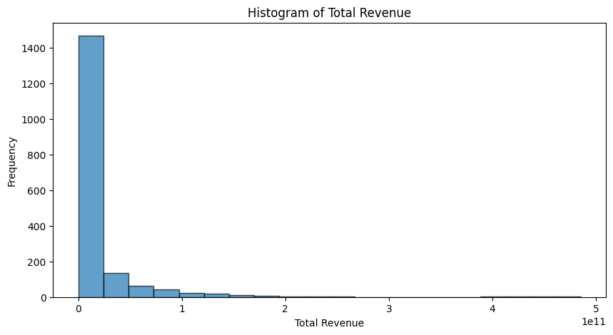

```python
plt.figure(figsize=(10, 5))
plt.hist(fundamentals_df['Total Revenue'], bins=20, edgecolor='black', alpha=0.7)
plt.title("Histogram of Total Revenue")
plt.xlabel("Total Revenue")
plt.ylabel("Frequency")
plt.show()
```

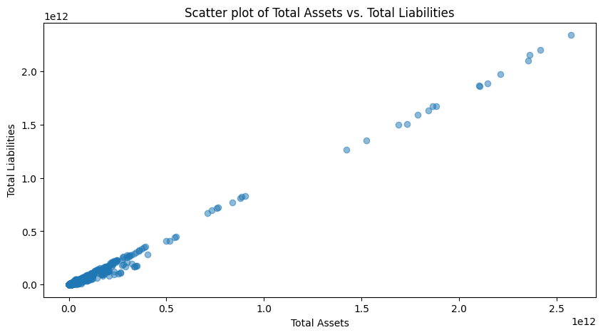

```python
#scatter plot of Total Assets vs Total Liabilities
plt.figure(figsize=(10, 5))
plt.scatter(fundamentals_df['Total Assets'], fundamentals_df['Total Liabilities'], alpha=0.5)
plt.title("Scatter plot of Total Assets vs. Total Liabilities")
plt.xlabel("Total Assets")
plt.ylabel("Total Liabilities")
plt.show()
```

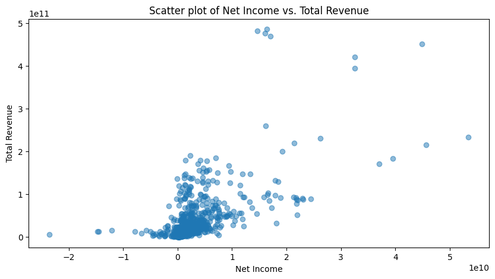

```python
#Scatter Plot of Net income vs Total Revenue:
plt.figure(figsize=(10, 5))
plt.scatter(fundamentals_df['Net Income'], fundamentals_df['Total Revenue'], alpha=0.5)
plt.title("Scatter plot of Net Income vs. Total Revenue")
plt.xlabel("Net Income")
plt.ylabel("Total Revenue")
plt.show()
```

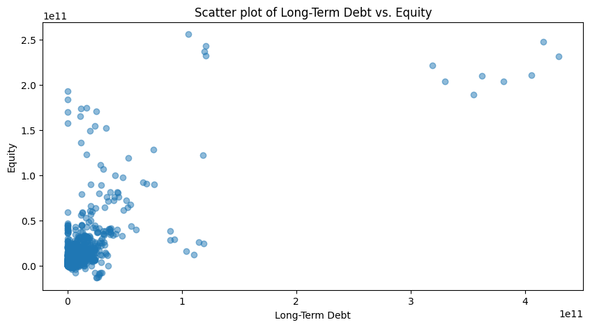

```python
#Scatter Plot of Long-Term Debt vs Equity:
plt.figure(figsize=(10, 5))
plt.scatter(fundamentals_df['Long-Term Debt'], fundamentals_df['Total Equity'], alpha=0.5)
plt.title("Scatter plot of Long-Term Debt vs. Equity")
plt.xlabel("Long-Term Debt")
plt.ylabel("Equity")
plt.show()
```

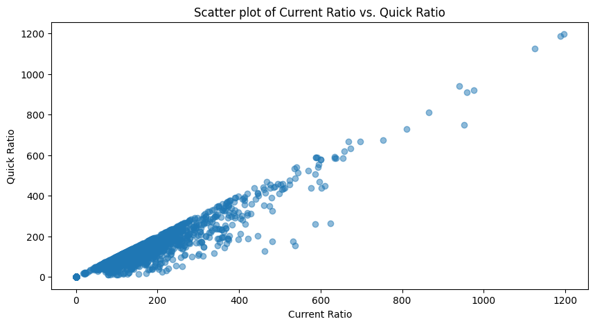

```python
#Scatter Plot of Current Ratio vs Quick Ratio:
plt.figure(figsize=(10, 5))
plt.scatter(fundamentals_df['Current Ratio'], fundamentals_df['Quick Ratio'], alpha=0.5)
plt.title("Scatter plot of Current Ratio vs. Quick Ratio")
plt.xlabel("Current Ratio")
plt.ylabel("Quick Ratio")
plt.show()
```

## Question 2

Linear Regression Model Development: Create linear regression to predict Estimated Shares Outstanding. Explain your model.

```python
#!pip install statsmodels

import statsmodels.formula.api as smf
```

```python
# Linear reggression to predict Estimated Shares outstanding
model_ESO = smf.ols(formula='Q("Estimated Shares Outstanding") ~ Q("Accounts Payable") + Q("Accounts Receivable") + Q("Add\'l income/expense items") + Q("After Tax ROE") + Q("Capital Expenditures") + Q("Capital Surplus") + Q("Cash Ratio") + Q("Cash and Cash Equivalents") + Q("Changes in Inventories") + Q("Common Stocks") + Q("Cost of Revenue") + Q("Current Ratio") + Q("Deferred Asset Charges") + Q("Deferred Liability Charges") + Q("Depreciation") + Q("Earnings Before Interest and Tax") + Q("Earnings Before Tax") + Q("Effect of Exchange Rate") + Q("Equity Earnings/Loss Unconsolidated Subsidiary") + Q("Fixed Assets") + Q("Goodwill") + Q("Gross Margin") + Q("Gross Profit") + Q("Income Tax") + Q("Intangible Assets") + Q("Interest Expense") + Q("Inventory") + Q("Investments") + Q("Liabilities") + Q("Long-Term Debt") + Q("Long-Term Investments") + Q("Minority Interest") + Q("Misc. Stocks") + Q("Net Borrowings") + Q("Net Cash Flow") + Q("Net Cash Flow-Operating") + Q("Net Cash Flows-Financing") + Q("Net Cash Flows-Investing") + Q("Net Income") + Q("Net Income Adjustments") + Q("Net Income Applicable to Common Shareholders") + Q("Net Income-Cont. Operations") + Q("Net Receivables") + Q("Non-Recurring Items") + Q("Operating Income") + Q("Operating Margin") + Q("Other Assets") + Q("Other Current Assets") + Q("Other Current Liabilities") + Q("Other Equity") + Q("Other Financing Activities") + Q("Other Investing Activities") + Q("Other Liabilities") + Q("Other Operating Activities") + Q("Other Operating Items") + Q("Pre-Tax Margin") + Q("Pre-Tax ROE") + Q("Profit Margin") + Q("Quick Ratio") + Q("Research and Development") + Q("Retained Earnings") + Q("Sale and Purchase of Stock") + Q("Sales, General and Admin.") + Q("Short-Term Debt / Current Portion of Long-Term Debt") + Q("Short-Term Investments") + Q("Total Assets") + Q("Total Current Assets") + Q("Total Current Liabilities") + Q("Total Equity") + Q("Total Liabilities") + Q("Total Liabilities & Equity") + Q("Total Revenue") + Q("Treasury Stock") + Q("For Year") + Q("Earnings Per Share")', data=fundamentals_df).fit()
```

```python
# Display the summary of the first regression model
model_ESO.summary()
```

OLS Regression Results

| Dep. Variable: | Q("Estimated Shares Outstanding") | R-squared: | 0.835 |
| --- | --- | --- | --- |
| Model: | OLS | Adj. R-squared: | 0.828 |
| Method: | Least Squares | F-statistic: | 117.0 |
| Date: | Thu, 18 Jan 2024 | Prob (F-statistic): | 0.00 |
| Time: | 11:26:55 | Log-Likelihood: | -37979. |
| No. Observations: | 1781 | AIC: | 7.611e+04 |
| Df Residuals: | 1706 | BIC: | 7.652e+04 |
| Df Model: | 74 |  |  |
| Covariance Type: | nonrobust |  |  |

|  | coef | std err | t | P>\|t\| | [0.025 | 0.975] |
| --- | --- | --- | --- | --- | --- | --- |
| Intercept | -3.662e+08 | 5.17e+07 | -7.078 | 0.000 | -4.68e+08 | -2.65e+08 |
| Q("Accounts Payable") | -0.0238 | 0.006 | -4.013 | 0.000 | -0.035 | -0.012 |
| Q("Accounts Receivable") | -0.0685 | 0.026 | -2.653 | 0.008 | -0.119 | -0.018 |
| Q("Add'l income/expense items") | 0.1818 | 0.031 | 5.846 | 0.000 | 0.121 | 0.243 |
| Q("After Tax ROE") | 1.121e+05 | 3.09e+05 | 0.363 | 0.717 | -4.94e+05 | 7.19e+05 |
| Q("Capital Expenditures") | 0.0423 | 0.015 | 2.887 | 0.004 | 0.014 | 0.071 |
| Q("Capital Surplus") | 0.0199 | 0.009 | 2.144 | 0.032 | 0.002 | 0.038 |
| Q("Cash Ratio") | 2.426e+05 | 3.46e+05 | 0.701 | 0.483 | -4.36e+05 | 9.21e+05 |
| Q("Cash and Cash Equivalents") | 0.0036 | 0.002 | 1.472 | 0.141 | -0.001 | 0.008 |
| Q("Changes in Inventories") | -0.0333 | 0.032 | -1.034 | 0.301 | -0.097 | 0.030 |
| Q("Common Stocks") | -0.0004 | 0.010 | -0.042 | 0.966 | -0.020 | 0.019 |
| Q("Cost of Revenue") | -0.0072 | 0.015 | -0.476 | 0.634 | -0.037 | 0.023 |
| Q("Current Ratio") | -1.124e+04 | 2.85e+05 | -0.039 | 0.969 | -5.71e+05 | 5.49e+05 |
| Q("Deferred Asset Charges") | -0.0051 | 0.010 | -0.518 | 0.605 | -0.025 | 0.014 |
| Q("Deferred Liability Charges") | -0.0279 | 0.008 | -3.376 | 0.001 | -0.044 | -0.012 |
| Q("Depreciation") | -0.0316 | 0.017 | -1.840 | 0.066 | -0.065 | 0.002 |
| Q("Earnings Before Interest and Tax") | -1.4952 | 0.272 | -5.495 | 0.000 | -2.029 | -0.961 |
| Q("Earnings Before Tax") | 1.0775 | 0.273 | 3.945 | 0.000 | 0.542 | 1.613 |
| Q("Effect of Exchange Rate") | -0.5483 | 0.119 | -4.617 | 0.000 | -0.781 | -0.315 |
| Q("Equity Earnings/Loss Unconsolidated Subsidiary") | 0.2490 | 0.058 | 4.326 | 0.000 | 0.136 | 0.362 |
| Q("Fixed Assets") | 0.0170 | 0.004 | 4.611 | 0.000 | 0.010 | 0.024 |
| Q("Goodwill") | 0.0069 | 0.004 | 1.538 | 0.124 | -0.002 | 0.016 |
| Q("Gross Margin") | -3.494e+05 | 6.42e+05 | -0.544 | 0.586 | -1.61e+06 | 9.1e+05 |
| Q("Gross Profit") | -0.0196 | 0.012 | -1.639 | 0.101 | -0.043 | 0.004 |
| Q("Income Tax") | 0.1273 | 0.057 | 2.231 | 0.026 | 0.015 | 0.239 |
| Q("Intangible Assets") | 0.0137 | 0.005 | 2.877 | 0.004 | 0.004 | 0.023 |
| Q("Interest Expense") | 1.3255 | 0.269 | 4.936 | 0.000 | 0.799 | 1.852 |
| Q("Inventory") | -0.0063 | 0.008 | -0.756 | 0.450 | -0.023 | 0.010 |
| Q("Investments") | -0.0075 | 0.004 | -1.700 | 0.089 | -0.016 | 0.001 |
| Q("Liabilities") | -0.0255 | 0.010 | -2.610 | 0.009 | -0.045 | -0.006 |
| Q("Long-Term Debt") | -0.0430 | 0.005 | -7.907 | 0.000 | -0.054 | -0.032 |
| Q("Long-Term Investments") | 0.0006 | 0.003 | 0.212 | 0.832 | -0.005 | 0.006 |
| Q("Minority Interest") | -0.0387 | 0.011 | -3.435 | 0.001 | -0.061 | -0.017 |
| Q("Misc. Stocks") | 0.0483 | 0.066 | 0.735 | 0.462 | -0.080 | 0.177 |
| Q("Net Borrowings") | 0.1113 | 0.018 | 6.269 | 0.000 | 0.076 | 0.146 |
| Q("Net Cash Flow") | -0.0056 | 0.050 | -0.113 | 0.910 | -0.103 | 0.092 |
| Q("Net Cash Flow-Operating") | 0.0170 | 0.049 | 0.348 | 0.728 | -0.079 | 0.113 |
| Q("Net Cash Flows-Financing") | -0.1323 | 0.053 | -2.500 | 0.013 | -0.236 | -0.028 |
| Q("Net Cash Flows-Investing") | -0.0003 | 0.050 | -0.006 | 0.995 | -0.098 | 0.097 |
| Q("Net Income") | 0.0772 | 0.189 | 0.408 | 0.683 | -0.293 | 0.448 |
| Q("Net Income Adjustments") | -0.0596 | 0.007 | -8.227 | 0.000 | -0.074 | -0.045 |
| Q("Net Income Applicable to Common Shareholders") | -0.0107 | 0.187 | -0.057 | 0.954 | -0.377 | 0.356 |
| Q("Net Income-Cont. Operations") | 0.0569 | 0.054 | 1.052 | 0.293 | -0.049 | 0.163 |
| Q("Net Receivables") | 0.0048 | 0.006 | 0.836 | 0.403 | -0.006 | 0.016 |
| Q("Non-Recurring Items") | 0.0674 | 0.018 | 3.675 | 0.000 | 0.031 | 0.103 |
| Q("Operating Income") | 0.3413 | 0.025 | 13.459 | 0.000 | 0.292 | 0.391 |
| Q("Operating Margin") | -4.121e+06 | 1.52e+06 | -2.704 | 0.007 | -7.11e+06 | -1.13e+06 |
| Q("Other Assets") | -0.0007 | 0.004 | -0.186 | 0.852 | -0.008 | 0.007 |
| Q("Other Current Assets") | 0.0137 | 0.011 | 1.214 | 0.225 | -0.008 | 0.036 |
| Q("Other Current Liabilities") | -0.0243 | 0.004 | -5.551 | 0.000 | -0.033 | -0.016 |
| Q("Other Equity") | 0.0225 | 0.011 | 2.060 | 0.040 | 0.001 | 0.044 |
| Q("Other Financing Activities") | 0.1247 | 0.018 | 7.045 | 0.000 | 0.090 | 0.159 |
| Q("Other Investing Activities") | -0.0112 | 0.006 | -1.874 | 0.061 | -0.023 | 0.001 |
| Q("Other Liabilities") | -0.0252 | 0.005 | -5.474 | 0.000 | -0.034 | -0.016 |
| Q("Other Operating Activities") | -0.0189 | 0.008 | -2.282 | 0.023 | -0.035 | -0.003 |
| Q("Other Operating Items") | 0.0275 | 0.013 | 2.179 | 0.029 | 0.003 | 0.052 |
| Q("Pre-Tax Margin") | 5.258e+06 | 1.91e+06 | 2.747 | 0.006 | 1.5e+06 | 9.01e+06 |
| Q("Pre-Tax ROE") | -7.942e+04 | 2.18e+05 | -0.364 | 0.716 | -5.07e+05 | 3.48e+05 |
| Q("Profit Margin") | -2.581e+06 | 1.92e+06 | -1.344 | 0.179 | -6.35e+06 | 1.19e+06 |
| Q("Quick Ratio") | -3.356e+05 | 4.43e+05 | -0.758 | 0.448 | -1.2e+06 | 5.32e+05 |
| Q("Research and Development") | 0.1088 | 0.019 | 5.663 | 0.000 | 0.071 | 0.146 |
| Q("Retained Earnings") | 0.0009 | 0.009 | 0.095 | 0.924 | -0.017 | 0.019 |
| Q("Sale and Purchase of Stock") | 0.1113 | 0.019 | 5.845 | 0.000 | 0.074 | 0.149 |
| Q("Sales, General and Admin.") | 0.0273 | 0.011 | 2.373 | 0.018 | 0.005 | 0.050 |
| Q("Short-Term Debt / Current Portion of Long-Term Debt") | -0.0020 | 0.006 | -0.362 | 0.718 | -0.013 | 0.009 |
| Q("Short-Term Investments") | 0.0343 | 0.007 | 5.125 | 0.000 | 0.021 | 0.047 |
| Q("Total Assets") | 0.0278 | 0.053 | 0.530 | 0.596 | -0.075 | 0.131 |
| Q("Total Current Assets") | 0.0263 | 0.004 | 6.035 | 0.000 | 0.018 | 0.035 |
| Q("Total Current Liabilities") | -0.0298 | 0.005 | -5.927 | 0.000 | -0.040 | -0.020 |
| Q("Total Equity") | -8.5879 | 0.880 | -9.760 | 0.000 | -10.314 | -6.862 |
| Q("Total Liabilities") | -8.5565 | 0.879 | -9.729 | 0.000 | -10.281 | -6.832 |
| Q("Total Liabilities & Equity") | 8.5532 | 0.883 | 9.688 | 0.000 | 6.822 | 10.285 |
| Q("Total Revenue") | 0.0054 | 0.015 | 0.355 | 0.723 | -0.024 | 0.035 |
| Q("Treasury Stock") | 0.0007 | 0.009 | 0.070 | 0.944 | -0.018 | 0.019 |
| Q("For Year") | 3.068e+05 | 1.89e+04 | 16.208 | 0.000 | 2.7e+05 | 3.44e+05 |
| Q("Earnings Per Share") | -2.878e+07 | 2.98e+06 | -9.648 | 0.000 | -3.46e+07 | -2.29e+07 |

| Omnibus: | 1044.324 | Durbin-Watson: | 1.644 |
| --- | --- | --- | --- |
| Prob(Omnibus): | 0.000 | Jarque-Bera (JB): | 165876.340 |
| Skew: | 1.705 | Prob(JB): | 0.00 |
| Kurtosis: | 50.156 | Cond. No. | 1.09e+16 |

Notes:  
[1] Standard Errors assume that the covariance matrix of the errors is correctly specified.  
[2] The condition number is large, 1.09e+16. This might indicate that there are  
strong multicollinearity or other numerical problems.

## Question 3

Multicollinearity in Linear Regression: Explain how multicollinearity can affect the interpretation of a linear regression model's coefficients.

In Linear Regression, Multicollinearity happens when two or more independent variables in the model are correlated with each other. It is important to note, however, that multicollinearity is not a problem of existence but a problem of degree. In other words, a high degree of collinearity between variables can affect the interpretation of the model's coefficients.

- First, it can inflate the standard errors of the coefficients, making them appear less statistically significant than they otherwise would be. This can lead to an erroneous inference about the relationship between predictors and the independent variable.
- Second, the coefficient estimates can become unstable. That is, small changes in the model can lead to large variations in the coefficients. Therefore, it becomes extremely challenging to see the true effect of each predictor on the dependent variable.

## Question 4

P-Value Analysis and Histogram: Create a histogram of the p-values. Is there any skewedness? Provide your explanation

```python
p_values = model_ESO.pvalues
```

```python
# I create an array of p-values. I exclude the intercept.
predictor_p_values = p_values.values
```

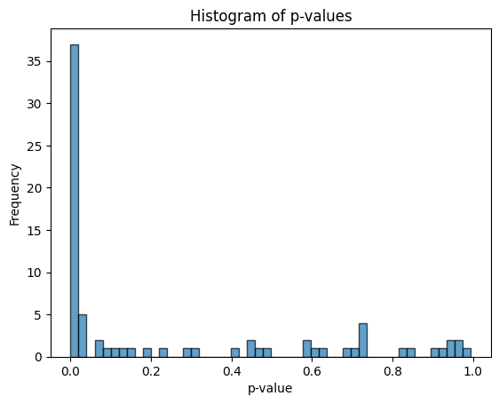

```python
# I plot the histogram
plt.hist(predictor_p_values, bins=50, edgecolor='black', alpha=0.7)
plt.title("Histogram of p-values")
plt.xlabel("p-value")
plt.ylabel("Frequency")
plt.show()
```

## Question 5

False Discovery Rate Control with BH Procedure: Given the p values you find, use the BH procedure to control the FDR with a q of 0.1. How many “true” discoveries do you estimate? (15 pts)

```
Alpha: 0.0395245938702212
```

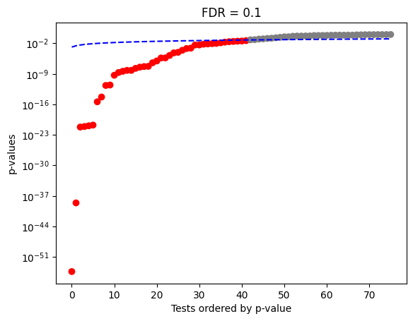

```python
def fdr(pvals, q, plotit=False):
    # Remove NA values
    pvals = np.array(pvals)
    pvals = pvals[~np.isnan(pvals)]
    # I sort the p-values and compute the FDR threshold
    N = len(pvals)
    sorted_pvals = np.sort(pvals)
    k = np.arange(1, N+1)
    fdr_threshold = (q * k) / N

    # I Find the last p-value that is below the FDR threshold
    below_threshold = sorted_pvals <= fdr_threshold
    max_index = np.max(np.where(below_threshold)) if np.any(below_threshold) else 0
    alpha = sorted_pvals[max_index]
    print(f"Alpha: {alpha}")
     # Optional plot
    if plotit:
        plt.scatter(range(N), sorted_pvals, c=np.where(sorted_pvals <= alpha, 'red', 'grey'), marker='o')
        plt.yscale('log')
        plt.plot(range(N), fdr_threshold, linestyle='--', color='blue')
        plt.xlabel("Tests ordered by p-value")
        plt.ylabel("p-values")
        plt.title(f"FDR = {q}")
        plt.show()

    return alpha

# Function is at 0.1 for q values
alpha = fdr(p_values, 0.1, plotit=True)
```

```python
true_discoveries = np.sum(p_values <= alpha)

print(f"There are are {true_discoveries} true_discoveries")
```

```
There are are 42 true_discoveries
```

## Question 6

Sensitivity Analysis of FDR Control: If you apply the BH procedure at different q values, how do the results change? What does this tell you about the robustness of your significant variables?

To apply the FDR procedure at different q values, I decided to make a list of possible q values, and run that list through a "for loop." Then, I count how many of the p-values are less than the alpha threshold.

```python
#I create the list of possible q values
qvals = [0.01, 0.05, 0.10, 0.15, 0.20]
q_results = []

#I create the for loop
for q in qvals:
    alpha = fdr(p_values, q, plotit=False)
    true_discoveries = np.sum(p_values <= alpha)
    q_results.append((q, true_discoveries))
    print(f"If the q value is {q}, then the 'true' discoveries are {true_discoveries}")
```

```
Alpha: 0.004069659719764579
If the q value is 0.01, then the 'true' discoveries are 31
Alpha: 0.022617603455001245
If the q value is 0.05, then the 'true' discoveries are 38
Alpha: 0.0395245938702212
If the q value is 0.1, then the 'true' discoveries are 42
Alpha: 0.06600693909992142
If the q value is 0.15, then the 'true' discoveries are 44
Alpha: 0.10145751883776309
If the q value is 0.2, then the 'true' discoveries are 46
```

Based on these results from q values set at 0.01, 0.05, 0.10, 0.15 and 0.20, one can see that, the alpha increases when the q values increase. As these increase, the number of 'true' discoveries also increases. By true discoveries, I mean how many p-values are below or equal the alpha threshold. Under that threshold, these are considered significant. Now, from the results, I can see that a very strict FDR level of q at 1%, I get 31 'true' discoveries. Then, as I relac the FDR threshold, the number of discoveries starts to increase until it reaches 46 at q = 20%. Since I obtained 31 discoveries at a very strict level of q (1%) I assume that can be considered rubust.

## Question 7

a. Expand your linear regression model by adding interaction terms. Create interaction terms between pairs of predictors (up to quadratic terms, i.e., terms of power two). You should include both original predictors and their interaction terms in your model.

```python
# Linear reggression to predict Estimated Shares outstanding
model_Interactions = smf.ols(formula='Q("Estimated Shares Outstanding") ~ Q("Accounts Payable") + Q("Accounts Receivable") + Q("Add\'l income/expense items") + Q("After Tax ROE") + Q("Capital Expenditures") + Q("Capital Surplus") + Q("Cash Ratio") + Q("Cash and Cash Equivalents") + Q("Changes in Inventories") + Q("Common Stocks") + Q("Cost of Revenue") + Q("Current Ratio") + Q("Deferred Asset Charges") + Q("Deferred Liability Charges") + Q("Depreciation") + Q("Earnings Before Interest and Tax") + Q("Earnings Before Tax") + Q("Effect of Exchange Rate") + Q("Equity Earnings/Loss Unconsolidated Subsidiary") + Q("Fixed Assets") + Q("Goodwill") + Q("Gross Margin") + I(Q("Gross Profit")**2) + Q("Income Tax") + I(Q("Intangible Assets")**2) + Q("Common Stocks"):Q("Cash and Cash Equivalents") + Q("Capital Expenditures"):Q("Gross Profit") + Q("Cash Ratio"):Q("Current Ratio") + Q("Earnings Before Interest and Tax"):Q("Income Tax") + Q("Gross Margin"):Q("Gross Profit")', data=fundamentals_df).fit()
```

```python
model_Interactions.summary()
```

OLS Regression Results

| Dep. Variable: | Q("Estimated Shares Outstanding") | R-squared: | 0.667 |
| --- | --- | --- | --- |
| Model: | OLS | Adj. R-squared: | 0.662 |
| Method: | Least Squares | F-statistic: | 146.5 |
| Date: | Thu, 18 Jan 2024 | Prob (F-statistic): | 0.00 |
| Time: | 11:26:55 | Log-Likelihood: | -38606. |
| No. Observations: | 1781 | AIC: | 7.726e+04 |
| Df Residuals: | 1756 | BIC: | 7.740e+04 |
| Df Model: | 24 |  |  |
| Covariance Type: | nonrobust |  |  |

|  | coef | std err | t | P>\|t\| | [0.025 | 0.975] |
| --- | --- | --- | --- | --- | --- | --- |
| Intercept | -2.596e-05 | 6.28e-06 | -4.134 | 0.000 | -3.83e-05 | -1.36e-05 |
| Q("Accounts Payable") | -0.0081 | 0.003 | -2.610 | 0.009 | -0.014 | -0.002 |
| Q("Accounts Receivable") | -0.0700 | 0.021 | -3.263 | 0.001 | -0.112 | -0.028 |
| Q("Add'l income/expense items") | -0.0042 | 0.027 | -0.155 | 0.877 | -0.057 | 0.049 |
| Q("After Tax ROE") | 3.007e-06 | 5.15e-07 | 5.843 | 0.000 | 2e-06 | 4.02e-06 |
| Q("Capital Expenditures") | 0.0188 | 0.019 | 0.987 | 0.324 | -0.019 | 0.056 |
| Q("Capital Surplus") | 0.0302 | 0.003 | 10.897 | 0.000 | 0.025 | 0.036 |
| Q("Cash Ratio") | 1.453e-08 | 2.9e-09 | 5.006 | 0.000 | 8.84e-09 | 2.02e-08 |
| Q("Cash and Cash Equivalents") | 0.0016 | 0.001 | 2.165 | 0.031 | 0.000 | 0.003 |
| Q("Changes in Inventories") | -0.0353 | 0.041 | -0.856 | 0.392 | -0.116 | 0.046 |
| Q("Common Stocks") | 0.0456 | 0.004 | 12.244 | 0.000 | 0.038 | 0.053 |
| Q("Cost of Revenue") | 0.0016 | 0.001 | 1.651 | 0.099 | -0.000 | 0.004 |
| Q("Current Ratio") | 1.855e-08 | 6.78e-09 | 2.736 | 0.006 | 5.25e-09 | 3.18e-08 |
| Q("Deferred Asset Charges") | -0.0493 | 0.007 | -6.748 | 0.000 | -0.064 | -0.035 |
| Q("Deferred Liability Charges") | 0.0185 | 0.008 | 2.258 | 0.024 | 0.002 | 0.035 |
| Q("Depreciation") | 0.0771 | 0.017 | 4.561 | 0.000 | 0.044 | 0.110 |
| Q("Earnings Before Interest and Tax") | -0.1748 | 0.028 | -6.183 | 0.000 | -0.230 | -0.119 |
| Q("Earnings Before Tax") | 0.2509 | 0.029 | 8.724 | 0.000 | 0.194 | 0.307 |
| Q("Effect of Exchange Rate") | -0.6634 | 0.114 | -5.796 | 0.000 | -0.888 | -0.439 |
| Q("Equity Earnings/Loss Unconsolidated Subsidiary") | 0.1346 | 0.056 | 2.407 | 0.016 | 0.025 | 0.244 |
| Q("Fixed Assets") | 0.0022 | 0.003 | 0.827 | 0.408 | -0.003 | 0.007 |
| Q("Goodwill") | 0.0018 | 0.004 | 0.504 | 0.614 | -0.005 | 0.009 |
| Q("Gross Margin") | 2.65e-09 | 1.81e-09 | 1.466 | 0.143 | -8.96e-10 | 6.2e-09 |
| I(Q("Gross Profit") ** 2) | 1.052e-13 | 5.31e-14 | 1.981 | 0.048 | 1.03e-15 | 2.09e-13 |
| Q("Income Tax") | -0.0930 | 0.032 | -2.901 | 0.004 | -0.156 | -0.030 |
| I(Q("Intangible Assets") ** 2) | -4.211e-15 | 4.8e-14 | -0.088 | 0.930 | -9.85e-14 | 9e-14 |
| Q("Common Stocks"):Q("Cash and Cash Equivalents") | 3.637e-14 | 8.48e-15 | 4.290 | 0.000 | 1.97e-14 | 5.3e-14 |
| Q("Capital Expenditures"):Q("Gross Profit") | 8.1e-13 | 3.42e-13 | 2.371 | 0.018 | 1.4e-13 | 1.48e-12 |
| Q("Cash Ratio"):Q("Current Ratio") | 1.052e-06 | 1.71e-06 | 0.616 | 0.538 | -2.3e-06 | 4.4e-06 |
| Q("Earnings Before Interest and Tax"):Q("Income Tax") | -8.98e-13 | 4.59e-13 | -1.958 | 0.050 | -1.8e-12 | 1.49e-15 |
| Q("Gross Margin"):Q("Gross Profit") | 0.0002 | 5.14e-05 | 3.477 | 0.001 | 7.78e-05 | 0.000 |

| Omnibus: | 814.759 | Durbin-Watson: | 1.422 |
| --- | --- | --- | --- |
| Prob(Omnibus): | 0.000 | Jarque-Bera (JB): | 269032.943 |
| Skew: | -0.865 | Prob(JB): | 0.00 |
| Kurtosis: | 63.186 | Cond. No. | 1.40e+16 |

Notes:  
[1] Standard Errors assume that the covariance matrix of the errors is correctly specified.  
[2] The condition number is large, 1.4e+16. This might indicate that there are  
strong multicollinearity or other numerical problems.

b. Briefly explain why interaction terms might be important in the context of predicting Estimated Shares Outstanding using fundamental financial metrics.

Interaction terms might be important becaise they allow us to capture the combined effects of two variables that might otherwise not be evident with each separate independent variable. For instance, "Common Stocks" and "Cash and Cash Equivalents" influence each other in ways that otherwise would not be evident. Moreover, interaction effects enhance the predictive power of the model as it allows it to be a better fit to the actual data.

Finally, from a strictly financial metrics perspective, interactions can improve financial planning, investment decisions, manage risk, and deploy more sofisticated corporate finance strategies.

## Question 8

Evaluate the performance of this new model with interaction terms. Compare it with the performance of the original model without interaction terms using appropriate metrics.

```python
# Linear reggression that includes interactions
model_Interactions = smf.ols(formula='Q("Estimated Shares Outstanding") ~ Q("Accounts Payable") + Q("Accounts Receivable") + Q("Add\'l income/expense items") + Q("After Tax ROE") + Q("Capital Expenditures") + Q("Capital Surplus") + Q("Cash Ratio") + Q("Cash and Cash Equivalents") + Q("Changes in Inventories") + Q("Common Stocks") + Q("Cost of Revenue") + Q("Current Ratio") + Q("Deferred Asset Charges") + Q("Deferred Liability Charges") + Q("Depreciation") + Q("Earnings Before Interest and Tax") + Q("Earnings Before Tax") + Q("Effect of Exchange Rate") + Q("Equity Earnings/Loss Unconsolidated Subsidiary") + Q("Fixed Assets") + Q("Goodwill") + Q("Gross Margin") + I(Q("Gross Profit")**2) + Q("Income Tax") + I(Q("Intangible Assets")**2) + Q("Common Stocks"):Q("Cash and Cash Equivalents") + Q("Capital Expenditures"):Q("Gross Profit") + Q("Cash Ratio"):Q("Current Ratio") + Q("Earnings Before Interest and Tax"):Q("Income Tax") + Q("Gross Margin"):Q("Gross Profit")', data=fundamentals_df).fit()
model_Interactions.summary()
```

OLS Regression Results

| Dep. Variable: | Q("Estimated Shares Outstanding") | R-squared: | 0.667 |
| --- | --- | --- | --- |
| Model: | OLS | Adj. R-squared: | 0.662 |
| Method: | Least Squares | F-statistic: | 146.5 |
| Date: | Thu, 18 Jan 2024 | Prob (F-statistic): | 0.00 |
| Time: | 11:26:55 | Log-Likelihood: | -38606. |
| No. Observations: | 1781 | AIC: | 7.726e+04 |
| Df Residuals: | 1756 | BIC: | 7.740e+04 |
| Df Model: | 24 |  |  |
| Covariance Type: | nonrobust |  |  |

|  | coef | std err | t | P>\|t\| | [0.025 | 0.975] |
| --- | --- | --- | --- | --- | --- | --- |
| Intercept | -2.596e-05 | 6.28e-06 | -4.134 | 0.000 | -3.83e-05 | -1.36e-05 |
| Q("Accounts Payable") | -0.0081 | 0.003 | -2.610 | 0.009 | -0.014 | -0.002 |
| Q("Accounts Receivable") | -0.0700 | 0.021 | -3.263 | 0.001 | -0.112 | -0.028 |
| Q("Add'l income/expense items") | -0.0042 | 0.027 | -0.155 | 0.877 | -0.057 | 0.049 |
| Q("After Tax ROE") | 3.007e-06 | 5.15e-07 | 5.843 | 0.000 | 2e-06 | 4.02e-06 |
| Q("Capital Expenditures") | 0.0188 | 0.019 | 0.987 | 0.324 | -0.019 | 0.056 |
| Q("Capital Surplus") | 0.0302 | 0.003 | 10.897 | 0.000 | 0.025 | 0.036 |
| Q("Cash Ratio") | 1.453e-08 | 2.9e-09 | 5.006 | 0.000 | 8.84e-09 | 2.02e-08 |
| Q("Cash and Cash Equivalents") | 0.0016 | 0.001 | 2.165 | 0.031 | 0.000 | 0.003 |
| Q("Changes in Inventories") | -0.0353 | 0.041 | -0.856 | 0.392 | -0.116 | 0.046 |
| Q("Common Stocks") | 0.0456 | 0.004 | 12.244 | 0.000 | 0.038 | 0.053 |
| Q("Cost of Revenue") | 0.0016 | 0.001 | 1.651 | 0.099 | -0.000 | 0.004 |
| Q("Current Ratio") | 1.855e-08 | 6.78e-09 | 2.736 | 0.006 | 5.25e-09 | 3.18e-08 |
| Q("Deferred Asset Charges") | -0.0493 | 0.007 | -6.748 | 0.000 | -0.064 | -0.035 |
| Q("Deferred Liability Charges") | 0.0185 | 0.008 | 2.258 | 0.024 | 0.002 | 0.035 |
| Q("Depreciation") | 0.0771 | 0.017 | 4.561 | 0.000 | 0.044 | 0.110 |
| Q("Earnings Before Interest and Tax") | -0.1748 | 0.028 | -6.183 | 0.000 | -0.230 | -0.119 |
| Q("Earnings Before Tax") | 0.2509 | 0.029 | 8.724 | 0.000 | 0.194 | 0.307 |
| Q("Effect of Exchange Rate") | -0.6634 | 0.114 | -5.796 | 0.000 | -0.888 | -0.439 |
| Q("Equity Earnings/Loss Unconsolidated Subsidiary") | 0.1346 | 0.056 | 2.407 | 0.016 | 0.025 | 0.244 |
| Q("Fixed Assets") | 0.0022 | 0.003 | 0.827 | 0.408 | -0.003 | 0.007 |
| Q("Goodwill") | 0.0018 | 0.004 | 0.504 | 0.614 | -0.005 | 0.009 |
| Q("Gross Margin") | 2.65e-09 | 1.81e-09 | 1.466 | 0.143 | -8.96e-10 | 6.2e-09 |
| I(Q("Gross Profit") ** 2) | 1.052e-13 | 5.31e-14 | 1.981 | 0.048 | 1.03e-15 | 2.09e-13 |
| Q("Income Tax") | -0.0930 | 0.032 | -2.901 | 0.004 | -0.156 | -0.030 |
| I(Q("Intangible Assets") ** 2) | -4.211e-15 | 4.8e-14 | -0.088 | 0.930 | -9.85e-14 | 9e-14 |
| Q("Common Stocks"):Q("Cash and Cash Equivalents") | 3.637e-14 | 8.48e-15 | 4.290 | 0.000 | 1.97e-14 | 5.3e-14 |
| Q("Capital Expenditures"):Q("Gross Profit") | 8.1e-13 | 3.42e-13 | 2.371 | 0.018 | 1.4e-13 | 1.48e-12 |
| Q("Cash Ratio"):Q("Current Ratio") | 1.052e-06 | 1.71e-06 | 0.616 | 0.538 | -2.3e-06 | 4.4e-06 |
| Q("Earnings Before Interest and Tax"):Q("Income Tax") | -8.98e-13 | 4.59e-13 | -1.958 | 0.050 | -1.8e-12 | 1.49e-15 |
| Q("Gross Margin"):Q("Gross Profit") | 0.0002 | 5.14e-05 | 3.477 | 0.001 | 7.78e-05 | 0.000 |

| Omnibus: | 814.759 | Durbin-Watson: | 1.422 |
| --- | --- | --- | --- |
| Prob(Omnibus): | 0.000 | Jarque-Bera (JB): | 269032.943 |
| Skew: | -0.865 | Prob(JB): | 0.00 |
| Kurtosis: | 63.186 | Cond. No. | 1.40e+16 |

Notes:  
[1] Standard Errors assume that the covariance matrix of the errors is correctly specified.  
[2] The condition number is large, 1.4e+16. This might indicate that there are  
strong multicollinearity or other numerical problems.

```python
# Linear regressionm model with no interactions
model_OLS = smf.ols(formula='Q("Estimated Shares Outstanding") ~ Q("Accounts Payable") + Q("Accounts Receivable") + Q("Add\'l income/expense items") + Q("After Tax ROE") + Q("Capital Expenditures") + Q("Capital Surplus") + Q("Cash Ratio") + Q("Cash and Cash Equivalents") + Q("Changes in Inventories") + Q("Common Stocks") + Q("Cost of Revenue") + Q("Current Ratio") + Q("Deferred Asset Charges") + Q("Deferred Liability Charges") + Q("Depreciation") + Q("Earnings Before Interest and Tax") + Q("Earnings Before Tax") + Q("Effect of Exchange Rate") + Q("Equity Earnings/Loss Unconsolidated Subsidiary") + Q("Fixed Assets") + Q("Goodwill") + Q("Gross Margin") + Q("Gross Profit") + Q("Income Tax") + Q("Intangible Assets")', data=fundamentals_df).fit()
```

```python
model_OLS.summary()
```

OLS Regression Results

| Dep. Variable: | Q("Estimated Shares Outstanding") | R-squared: | 0.670 |
| --- | --- | --- | --- |
| Model: | OLS | Adj. R-squared: | 0.666 |
| Method: | Least Squares | F-statistic: | 142.7 |
| Date: | Thu, 18 Jan 2024 | Prob (F-statistic): | 0.00 |
| Time: | 11:26:55 | Log-Likelihood: | -38597. |
| No. Observations: | 1781 | AIC: | 7.725e+04 |
| Df Residuals: | 1755 | BIC: | 7.739e+04 |
| Df Model: | 25 |  |  |
| Covariance Type: | nonrobust |  |  |

|  | coef | std err | t | P>\|t\| | [0.025 | 0.975] |
| --- | --- | --- | --- | --- | --- | --- |
| Intercept | 1.012e+08 | 4.59e+07 | 2.204 | 0.028 | 1.12e+07 | 1.91e+08 |
| Q("Accounts Payable") | -0.0011 | 0.003 | -0.406 | 0.685 | -0.006 | 0.004 |
| Q("Accounts Receivable") | -0.0592 | 0.021 | -2.783 | 0.005 | -0.101 | -0.017 |
| Q("Add'l income/expense items") | -0.0165 | 0.027 | -0.622 | 0.534 | -0.069 | 0.036 |
| Q("After Tax ROE") | -2.389e+04 | 6.41e+04 | -0.373 | 0.710 | -1.5e+05 | 1.02e+05 |
| Q("Capital Expenditures") | 0.0408 | 0.016 | 2.499 | 0.013 | 0.009 | 0.073 |
| Q("Capital Surplus") | 0.0288 | 0.003 | 10.738 | 0.000 | 0.024 | 0.034 |
| Q("Cash Ratio") | 6.36e+05 | 3.19e+05 | 1.995 | 0.046 | 1.08e+04 | 1.26e+06 |
| Q("Cash and Cash Equivalents") | 0.0024 | 0.001 | 3.072 | 0.002 | 0.001 | 0.004 |
| Q("Changes in Inventories") | -0.0333 | 0.041 | -0.811 | 0.417 | -0.114 | 0.047 |
| Q("Common Stocks") | 0.0566 | 0.003 | 19.592 | 0.000 | 0.051 | 0.062 |
| Q("Cost of Revenue") | -0.0006 | 0.001 | -0.629 | 0.529 | -0.002 | 0.001 |
| Q("Current Ratio") | -2.583e+04 | 2.23e+05 | -0.116 | 0.908 | -4.63e+05 | 4.11e+05 |
| Q("Deferred Asset Charges") | -0.0453 | 0.007 | -6.223 | 0.000 | -0.060 | -0.031 |
| Q("Deferred Liability Charges") | 0.0179 | 0.008 | 2.190 | 0.029 | 0.002 | 0.034 |
| Q("Depreciation") | 0.0475 | 0.017 | 2.805 | 0.005 | 0.014 | 0.081 |
| Q("Earnings Before Interest and Tax") | -0.1460 | 0.027 | -5.462 | 0.000 | -0.198 | -0.094 |
| Q("Earnings Before Tax") | 0.1970 | 0.027 | 7.409 | 0.000 | 0.145 | 0.249 |
| Q("Effect of Exchange Rate") | -0.7743 | 0.110 | -7.032 | 0.000 | -0.990 | -0.558 |
| Q("Equity Earnings/Loss Unconsolidated Subsidiary") | 0.0459 | 0.036 | 1.289 | 0.198 | -0.024 | 0.116 |
| Q("Fixed Assets") | 0.0034 | 0.002 | 1.377 | 0.169 | -0.001 | 0.008 |
| Q("Goodwill") | -0.0031 | 0.004 | -0.818 | 0.413 | -0.011 | 0.004 |
| Q("Gross Margin") | -9.906e+05 | 7.38e+05 | -1.342 | 0.180 | -2.44e+06 | 4.58e+05 |
| Q("Gross Profit") | 0.0147 | 0.003 | 4.922 | 0.000 | 0.009 | 0.021 |
| Q("Income Tax") | -0.0955 | 0.031 | -3.114 | 0.002 | -0.156 | -0.035 |
| Q("Intangible Assets") | 0.0072 | 0.004 | 1.715 | 0.086 | -0.001 | 0.016 |

| Omnibus: | 629.961 | Durbin-Watson: | 1.401 |
| --- | --- | --- | --- |
| Prob(Omnibus): | 0.000 | Jarque-Bera (JB): | 224037.584 |
| Skew: | -0.046 | Prob(JB): | 0.00 |
| Kurtosis: | 57.946 | Cond. No. | 1.78e+11 |

Notes:  
[1] Standard Errors assume that the covariance matrix of the errors is correctly specified.  
[2] The condition number is large, 1.78e+11. This might indicate that there are  
strong multicollinearity or other numerical problems.

```
R-squared and Adjusted R-squared:
    The new model has an R-squared of 0.667 and an Adjusted R-squared of 0.662.
    The original model has an R-squared of 0.670 and an Adjusted R-squared of 0.666.
```

We can say that both models explain a similar proportion of variance in 'Estimated Shares Outstanding'. The slight decrease in R-squared for the new model indicates that the additional complexity (interaction and quadratic terms) does not significantly improve the model's explanatory power.

```
AIC and BIC: Both models have a similar AIC (~7.726e+04 for the new model and ~7.725e+04 for the original model), indicating that the model's fit to the data, when accounting for the number of predictors, is similar.
```

Significance of Predictors:

```
In the new model, certain predictors and interaction terms are statistically significant, indicating meaningful relationships with 'Estimated Shares Outstanding'.
However, we can se that the introduction of interaction and quadratic terms does not drastically change the significance of most original predictors, suggesting that the main effects are still relevant in the presence of interactions and non-linear terms.
```

Some variables and interaction terms have higher p-values, indicating that they are not statistically significant at the 5% level. Examples include:

[output not shown]

For these terms, the evidence is weaker that there's a real relationship with 'Estimated Shares Outstanding'. Non-significant terms don't necessarily mean there's no relationship, but they suggest that the relationship is not statistically detectable based on the data you have.

## Question 9

a. Create a histogram of the p-values for the new model including interaction terms. Discuss any noticeable differences from the histogram you created for the original model. (3pts)

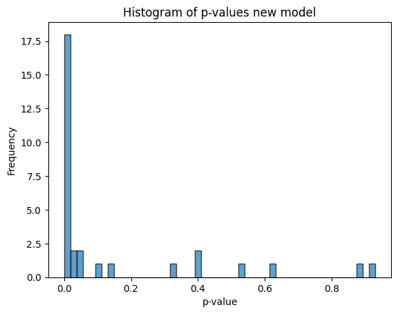

```python
p_values_nm = model_Interactions.pvalues
predictor_p_values_nm = p_values_nm.values
plt.hist(predictor_p_values_nm, bins=50, edgecolor='black', alpha=0.7)
plt.title("Histogram of p-values new model")
plt.xlabel("p-value")
plt.ylabel("Frequency")
plt.show()
```

b. Apply the Benjamini-Hochberg (BH) procedure to control the False Discovery Rate (FDR) with a q-value of 0.1. How many significant predictors are identified now, including both main effects and interaction effects? (5pts)

```
Alpha: 0.0503804816521099
```

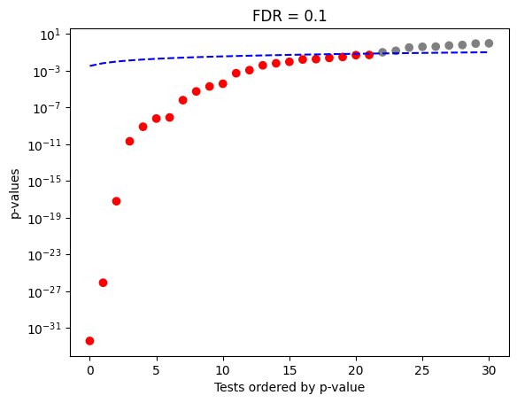

[output not shown]

```python
# Function is at 0.1 for q values
alpha = fdr(p_values_nm, 0.1, plotit=True)
significant_predictors = np.sum(p_values_nm <= alpha)

print(f"There are {significant_predictors} significant predictors, including significant main effects and interaction effects")
```

c. Compare these results with those obtained from the original model. Discuss the impact of including interaction terms on the number of discoveries and the control of the FDR. (2pts)